# Breast Cancer Binary Classification

```
Author: Thu Thi Nguyen
```

## 1.1. Summary

In this project, I built and optimised (Hyperparameter Tuning) a deep neural network to predict breast cancer. The task is to classify tumours into **Malignant** or **Benign** type when provided with the tumour's attributes in the dataset. This is a **binary classification** problem.

Similar dataset can be found here: https://www.kaggle.com/datasets/uciml/breast-cancer-wisconsin-data

To find the best neural network, I tried various deep learning networks with different configurations of hyperparameters, features, intialization methods and compared their performances. The best neural network was found by using grid search (**RandomizedSearchCV**) method.

```python
## Import Common Python Libraries
import numpy as np
import pandas as pd
import os
import seaborn as sns

## Import matplotlib and some default setup for figures
%matplotlib inline
import matplotlib as mpl
import matplotlib.pyplot as plt
mpl.rc('axes', labelsize=14)
mpl.rc('xtick', labelsize=12)
mpl.rc('ytick', labelsize=12)

## Import Tensorflow, and grid search libraries
import tensorflow as tf
from tensorflow import keras
from scipy.stats import reciprocal
from sklearn.model_selection import RandomizedSearchCV
from sklearn.model_selection import GridSearchCV

print('tensorflow version: ' + tf.__version__)
print('keras version: ' + keras.__version__)
```

```
tensorflow version: 2.11.0
keras version: 2.11.0
```

## 1.2. Data Exploration & Preparation

First, let's load the dataset and see how it's look like.

```python
path0 = r"C:\Users\SOGCNZ\Jupyter_Projects\ML_AI"
fname = "breast_cancer_data.csv"
path1 = f"{path0}/{fname}"
df = pd.read_csv(path1)
print('The data shape is: ' + str(df.shape))
df.head(2)
```

```
The data shape is: (25524, 32)
```

|  | id | diagnosis | radius_mean | texture_mean | perimeter_mean | area_mean | smoothness_mean | compactness_mean | concavity_mean | concave points_mean | ... | radius_worst | texture_worst | perimeter_worst | area_worst | smoothness_worst | compactness_worst | concavity_worst | concave points_worst | symmetry_worst | fractal_dimension_worst |
| --- | --- | --- | --- | --- | --- | --- | --- | --- | --- | --- | --- | --- | --- | --- | --- | --- | --- | --- | --- | --- | --- |
| 0 | 0 | 1 | 18.382336 | 7.256714 | 91.377706 | 451.701127 | 0.078681 | 0.135853 | 0.290649 | 0.120906 | ... | 26.770957 | 13.025038 | 116.746455 | 962.654199 | 0.118997 | 0.319514 | 0.783059 | 0.198664 | 0.529692 | 0.160792 |
| 1 | 1 | 0 | 10.302042 | 16.758441 | 97.568306 | 320.033091 | 0.129037 | 0.090188 | 0.043289 | 0.018798 | ... | 13.444048 | 25.704716 | 96.355024 | 219.245739 | 0.157770 | 0.122358 | 0.022506 | 0.109841 | 0.279209 | 0.075751 |

2 rows × 32 columns

By using following command, I can see that the data has No missing value!

```python
df.isnull().sum()
```

```
id                         0
diagnosis                  0
radius_mean                0
texture_mean               0
perimeter_mean             0
area_mean                  0
smoothness_mean            0
compactness_mean           0
concavity_mean             0
concave points_mean        0
symmetry_mean              0
fractal_dimension_mean     0
radius_se                  0
texture_se                 0
perimeter_se               0
area_se                    0
smoothness_se              0
compactness_se             0
concavity_se               0
concave points_se          0
symmetry_se                0
fractal_dimension_se       0
radius_worst               0
texture_worst              0
perimeter_worst            0
area_worst                 0
smoothness_worst           0
compactness_worst          0
concavity_worst            0
concave points_worst       0
symmetry_worst             0
fractal_dimension_worst    0
dtype: int64
```

### 1.2.1. Split data to train set and test set.

I will split the original dataset into training and testing sets. The sizes of train and test sets are 85% and 15% of the original data, respectively. The train_test_split uses "random_state=42" to control the shuffling applied to the data before applying the split.

```python
from sklearn.model_selection import train_test_split

df_train, df_test = train_test_split(df, test_size=0.15, random_state=42)
df_train = df_train.reset_index(drop=True)
df_test = df_test.reset_index(drop=True)
```

### 1.2.2. Remove un-related features and outliers

**First, I will drop features which have low correlation scores with y-variable: "diagnosis"**

- Since the data has 30 features which may be to many, I will check the correlation scores of all features with y-variable (which is "diagnosis" column) to see whether I can **drop some features with very low correlation scores**.
- As shown below, "id" and "smoothness_worst" have very low correlation scores with "diagnosis". Therefore, they will be droped. Also, I observed that "smoothness_worst" can be also droped. (my model accuracy increased when I droped this feature).

```python
corr_matrix = df_train.corr()
corr_matrix["diagnosis"].sort_values(ascending=False)
```

```
diagnosis                  1.000000
concavity_mean             0.751175
concave points_worst       0.723203
perimeter_worst            0.697751
concave points_mean        0.688961
radius_worst               0.636476
area_worst                 0.593724
perimeter_se               0.590172
compactness_mean           0.577870
area_mean                  0.525581
concavity_worst            0.494766
area_se                    0.485042
radius_mean                0.473129
perimeter_mean             0.466732
radius_se                  0.439507
symmetry_mean              0.423952
smoothness_mean            0.420520
concavity_se               0.374827
fractal_dimension_worst    0.362407
compactness_worst          0.345808
compactness_se             0.323582
concave points_se          0.315438
fractal_dimension_se       0.301219
texture_mean               0.301152
symmetry_worst             0.222119
texture_worst              0.207785
symmetry_se                0.183468
texture_se                 0.114396
fractal_dimension_mean     0.111353
smoothness_worst           0.036921
id                        -0.006727
smoothness_se             -0.088874
Name: diagnosis, dtype: float64
```

```python
# Drop 2 columns: ID & smoothness_worst
df_train = df_train.drop(['id','smoothness_worst'], axis=1)
df_train.shape
```

```
(21695, 30)
```

**Second, I will find features with high AutoCorrelation score**

- There may have some features that highly correlate to the others. If the data is in that situation, the highly correlated features need to be combined and one/some of them can be removed.
- By checking the **autocorrelation score** between variables, I can find highly correlated features.
- In the function below, the input is my data set (without y-variable: the "diagnosis" column). The threshold is the correlation score limit that I want to check. The function with return a set of correlated features with the threshold limit I choose.
- I will set the threshold = 0.7 since I want to find highly correlated features. As you can see, with threshold = 0.7, there is no correlated features found. Note that, if the threshold is set with a small value such as 0.3, there are many correlated features. But that is not what I want.

```python
## Here, I write a function to sheck whether the data has highly correlated features or not.
def correlation(dataset, threshold):
    col_corr = set()  # Set of all the names of correlated columns
    corr_matrix = dataset.corr()
    for i in range(len(corr_matrix.columns)):
        for j in range(i):
            if abs(corr_matrix.iloc[i, j]) > threshold: # we are interested in absolute coeff value
                colname = corr_matrix.columns[i]  # getting the name of column
                col_corr.add(colname)
    return col_corr
```

```python
## I will set the threshold = 0.7 since I wnat to find highly correlated features
df_trainnew = df_train.drop('diagnosis', axis=1)

corr_features = correlation(df_trainnew, 0.7)
print('Number correlated features: ', len(set(corr_features)))
if len(set(corr_features))>0:
    print('They are: ', corr_features)
```

```
Number correlated features:  0
```

**Third, I will remove outliers**

- First, I can use box plots for quick views of how the data is distributed. I observed that there are many outliers in the dataset, but should I remove them?
- Since this problem is about cancer detection, some outliers may be very important information to detect cancer. Therefore, remove all of them (which is a alot) is not a good idea.
- Therefore, I came up with another method to remove just few outliers. I will use **clustering** to group the data into different groups. Only data points that are really far from all groups can be considered as outliers (since they are not belong to any group) and be removed.

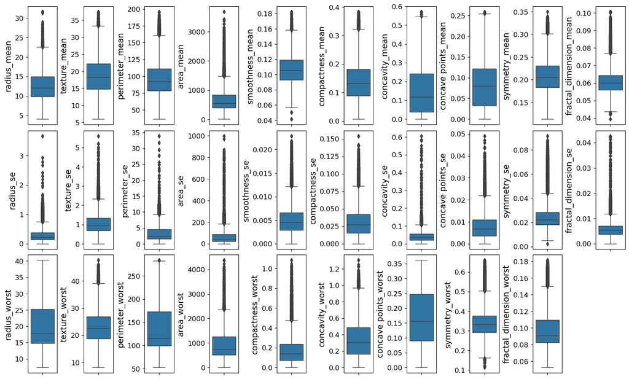

```python
cols = df_train.columns.to_list()[1:]

plt.rc('font', size=12)
fig = plt.figure(figsize=(15, 9),constrained_layout=True)
fig.tight_layout()

for i in range(len(cols)):
    plt.subplot(3,10,i+1)
    sns.boxplot(y=df_train[cols[i]], linewidth=1)
    plt.ylabel(cols[i])
```

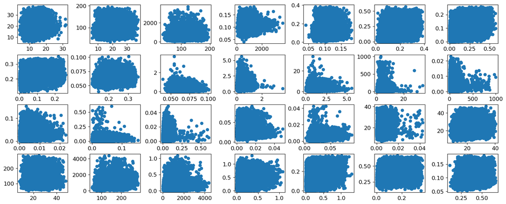

```python
plt.rc('font', size=12)
fig = plt.figure(figsize=(15, 6),constrained_layout=True)
fig.tight_layout()

for i in range(len(cols)-1):
    plt.subplot(4,7,i+1)
    plt.scatter(df_train[cols[i]],df_train[cols[i+1]])
```

- The scatter plots above show me that some scatters have **non-spherical shapes** but very good density. Therefore, I will not use K-Means clustering (since K-Means does not work well with non-spherical shape clusters). Instead, I will use DBSCAN clustering.
- In the function below, I will use DBSCAN for clustering my data. The function returns data points that do not belong to any cluster (by checking their lables = -1 or not).
- Note that, I set "eps=40" to ensure very large distance for the DBSCAN clustering. Therefore, I will only remove the data points that are really far from all other points. This will help to avoid removal of useful data points.

```python
def apply_DBscan(df_train, col_nameX, col_nameY, remove_id):
    dbscan.fit(df_train[[col_nameY, col_nameX]])

    ids = df_train.loc[dbscan.labels_==-1].index
    if len(ids)>0:
        remove_id.append(ids)

    return remove_id
```

```python
# use DBScan to remove outliers
from sklearn.cluster import DBSCAN
dbscan = DBSCAN(eps=40, min_samples=5)

remove_id = []
col_nameY = 'diagnosis'
for col in df_train.columns:
    remove_id = apply_DBscan(df_train, col, col_nameY, remove_id)

flat_list_id = [item for sublist in remove_id for item in sublist]
```

```python
df_train.loc[flat_list_id,'diagnosis'].value_counts()
```

```
1    18
0     4
Name: diagnosis, dtype: int64
```

```python
df_train['diagnosis'].value_counts()
```

```
0    10867
1    10828
Name: diagnosis, dtype: int64
```

```python
df_train = df_train.drop(flat_list_id)
df_train = df_train.reset_index(drop=True)
```

- In the code above, **flat_list_id** is a list that contains the indexes of data points that need to be removed. There are 22 data points that will be removed in which 18 data points with 'diagnosis' = 1, and 4 points with 'diagnosis' = 0.
- The original data has 10867 points with 'diagnosis' = 0 and 10828 with 'diagnosis' = 1. Therefore, removing only 22 points will not be to much.

### 1.2.3. Split training data into train set and valid set - Scale data for training models

One traditional method for split data is use **K-fold cross-vaidation** method. However, in this project, I want to try with various options and features for various type of networks, and training each Deep learning model really takes time. Therefore, instead of using K-fold cross-vaidation, I will use **stratified sampling method** using **StratifiedShuffleSplit** function inside sklearn.

```python
from sklearn.preprocessing import StandardScaler
from sklearn.model_selection import StratifiedShuffleSplit

X = df_train.drop('diagnosis', axis=1)
y = df_train['diagnosis']

split = StratifiedShuffleSplit(n_splits=1, test_size=0.15, random_state=42)

for train_index, test_index in split.split(X, y):
    X_train = X.iloc[train_index, :]
    X_valid = X.iloc[test_index, :]
    y_train = y.iloc[train_index]
    y_valid = y.iloc[test_index]

scaler = StandardScaler()
X_train_scaled = scaler.fit_transform(X_train)
X_valid_scaled = scaler.fit_transform(X_valid)
```

## 1.3. Build and Fine-tune a dense deep neural network

- Here, I will try several methods of initialisation including He, Lecun and Glorot.
- For each type of initialisation, I built a Keras model using Randomised Search CV to obtain the optimal hyperparameters and features for the model.
- Additionally, I tried different multiple drop-out methods in between layers. However, it did not improve performance.
- Picture below shows recommendations for initialization parameters for each type of activation function:

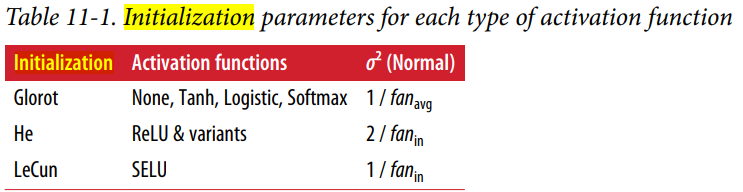

### 1.3.1. He normalisation

- I developed function below to build a **Sequential** network. The function will automatically create a dense deep neural network based on the inputs for *n_hidden, n_neurons, learning_rate, activation, optimizer, input_shape*.
- Since, the final output is binary (1 or 0), I need to add the last layer wiith **only one output** with the **logistic activation (sigmoid)**.
- The metrics to meassure model's performance is model's accuracy.

```python
# First, let's create possible optimisers for my models
SGD = keras.optimizers.SGD(momentum=0.9)
Adagrad = keras.optimizers.Adagrad()
RMSprop = keras.optimizers.RMSprop (rho=0.9)
Adam = keras.optimizers.Adam(beta_1=0.9, beta_2=0.999)
```

```python
def he_model(n_hidden, n_neurons, learning_rate, activation, optimizer, input_shape=X_train.shape[1:]):
    model = keras.models.Sequential()
    model.add (keras.layers.InputLayer(input_shape=input_shape))
    for layer in range(n_hidden):
         model.add(keras.layers.Dense(n_neurons, activation, kernel_initializer="he_normal",kernel_regularizer=keras.regularizers.l2(0.01)))
    model.add(keras.layers.Dense(1, activation='sigmoid'))
    model.compile(loss=tf.keras.losses.BinaryCrossentropy(from_logits=False), optimizer=optimizer, metrics=['accuracy'])
    return model
```

- Now, I will Create a KerasClassifier using built-function as he_model.
- To fine-tune the best network, I tried following options for network's parameters:

[output not shown]

- **RandomizedSearchCV** was used to find the best model. The **EarlyStopping(patience=10)** means that the training will stop if there is no improvement of model's accuracy after 10 trials.
- As you can see, the best model I found is the one with following parameters: {'activation': 'LeakyReLU', 'learning_rate': 0.005172415563224279, 'n_hidden': 4, 'n_neurons': 153, 'optimizer': 'SGD'} 0.981825073560079

```python
# Create a KerasClassifier
keras_clasifier= keras.wrappers.scikit_learn.KerasClassifier(build_fn = he_model)
param_distribs = {"n_neurons": np.arange(1, 200),
                  "n_hidden": np.arange (2,9),
                  "activation":["relu","LeakyReLU","elu"],
                  "optimizer": ["SGD","Adagrad","RMSprop","Adam"],
                  "learning_rate": reciprocal(3e-4, 3e-2)}

#### Using RandomizedSearchCV
rnd_search_cv = RandomizedSearchCV(keras_clasifier, param_distribs, n_iter=10, cv=3)
rnd_search_cv.fit(X_train_scaled, y_train, epochs=100,
                  validation_data=(X_valid_scaled, y_valid),
                  callbacks=[keras.callbacks.EarlyStopping(patience=10)], verbose=0)

print(rnd_search_cv.best_params_)
print(rnd_search_cv.best_score_)
```

```
{'activation': 'LeakyReLU', 'learning_rate': 0.005172415563224279, 'n_hidden': 4, 'n_neurons': 153, 'optimizer': 'SGD'}
0.981825073560079
```

### 1.3.2. Lecun normalisation

- Lecun normalisation works similar to the Glorot initliasation method, emplores a similar distribution to initalise weights, but with a slight change in the standard deviation where instead of dividing 1 by the average of fan-in and fan-out, the inputs and neurons for the layer, Lecun uses only the fan-in of inputs.
- Similar to the previous section, a function named "lecun_model" is developed to create Sequential network based on inputs. The RandomizedSearchCV was used with the same EarlyStopping option.

```python
def lecun_model(n_hidden, n_neurons, learning_rate,activation,optimizer, input_shape=X_train.shape[1:]):
    model = keras.models.Sequential()
    model.add (keras.layers.InputLayer(input_shape=input_shape))
    for layer in range(n_hidden):
         model.add(keras.layers.Dense(n_neurons, activation, kernel_initializer="lecun_normal",kernel_regularizer=keras.regularizers.l2(0.01)))
    model.add(keras.layers.Dense(1,activation='sigmoid'))
    model.compile(loss=tf.keras.losses.BinaryCrossentropy(from_logits=False), optimizer=optimizer, metrics=['accuracy'])
    return model
```

```python
keras_clasifier_lecun = keras.wrappers.scikit_learn.KerasClassifier(lecun_model)
param_distribs_lecun = {"n_neurons": np.arange(1, 200),
                  "n_hidden": np.arange (2,9),
                  "activation":["selu","elu"],
                  "optimizer": ["SGD","Adagrad","RMSprop","Adam"],
                  "learning_rate": reciprocal(3e-4, 3e-2)}
#### Using RandomizedSearchCV
rnd_search_cv_lecun = RandomizedSearchCV(keras_clasifier_lecun, param_distribs_lecun, n_iter=10, cv=3)
rnd_search_cv_lecun.fit(X_train_scaled, y_train, epochs=100,
                  validation_data=(X_valid_scaled, y_valid),
                  callbacks=[keras.callbacks.EarlyStopping(patience=10)], verbose=0)

print(rnd_search_cv_lecun.best_params_)
print(rnd_search_cv_lecun.best_score_)
```

```
{'activation': 'selu', 'learning_rate': 0.006482727568590184, 'n_hidden': 7, 'n_neurons': 110, 'optimizer': 'Adagrad'}
0.9818793336550394
```

### 1.3.3. Glorot normalisation

```python
def glorot_model(n_hidden, n_neurons, learning_rate,activation,optimizer, input_shape=X_train.shape[1:]):
    model = keras.models.Sequential()
    model.add (keras.layers.InputLayer(input_shape=input_shape))
    for layer in range(n_hidden):
         model.add(keras.layers.Dense(n_neurons, activation, kernel_initializer="GlorotUniform",kernel_regularizer=keras.regularizers.l2(0.01)))
    model.add(keras.layers.Dense(1,activation='sigmoid'))
    model.compile(loss=tf.keras.losses.BinaryCrossentropy(from_logits=False), optimizer=optimizer, metrics=['accuracy'])
    return model
```

```python
keras_clasifier_glorot = keras.wrappers.scikit_learn.KerasClassifier(glorot_model)
param_distribs_glorot = {"n_neurons": np.arange(1, 200),
                  "n_hidden": np.arange (2,9),
                  "activation":["selu","elu","relu","LeakyReLU","softmax","tanh","sigmoid"],
                  "optimizer": ["SGD","Adagrad","RMSprop","Adam"],
                  "learning_rate": reciprocal(3e-4, 3e-2)}
#### Using RandomizedSearchCV
rnd_search_cv_glorot = RandomizedSearchCV(keras_clasifier_glorot, param_distribs_glorot, n_iter=10, cv=3)
rnd_search_cv_glorot.fit(X_train_scaled, y_train, epochs=100,
                  validation_data=(X_valid_scaled, y_valid),
                  callbacks=[keras.callbacks.EarlyStopping(patience=10)], verbose=0)

print(rnd_search_cv_glorot.best_params_)
print(rnd_search_cv_glorot.best_score_)
```

```
{'activation': 'relu', 'learning_rate': 0.0012467471029700035, 'n_hidden': 7, 'n_neurons': 89, 'optimizer': 'Adagrad'}
0.9816623330116272
```

### 1.3.4. Save model & make prediction

As shown below, three models have very similar accuracy. The NN with Lecun and he activation function have slightly higher accuracy. Therefore, I will keep all three models and try to make predictions for test data.

```python
print('Best score he:', str(rnd_search_cv.best_score_))
print('Best score lecun:', str(rnd_search_cv_lecun.best_score_))
print('Best score glorot:', str(rnd_search_cv_glorot.best_score_))
```

```
Best score he: 0.981825073560079
Best score lecun: 0.9818793336550394
Best score glorot: 0.9816623330116272
```

Fiest, I will re-call the best model for each type and save them for future usages.

```python
# recall the best model for each type of activation function
model_he = rnd_search_cv.best_estimator_.model
model_lecun = rnd_search_cv_lecun.best_estimator_.model
model_glorot = rnd_search_cv_glorot.best_estimator_.model

# save models
model_he.save("model_he.h5")
model_lecun.save("model_lecun.h5")
model_glorot.save("model_glorot.h5")
```

Let me make predictions:

```python
## re-call kept columns for X_train
columns = X_train.columns.to_list()

## prepare X_test
X_test = df_test[columns]
y_test = df_test['diagnosis']

## Scale X_test
X_test_scaled = scaler.fit_transform(X_test)

## Make predictions
y_pred_he = (model_he.predict(X_test_scaled)).round()
y_pred_lecun = (model_lecun.predict(X_test_scaled)).round()
y_pred_glorot = (model_glorot.predict(X_test_scaled)).round()

## Check model score
from sklearn.metrics import accuracy_score
accuracy_he = accuracy_score(y_test, y_pred_he)
accuracy_lecun = accuracy_score(y_test, y_pred_lecun)
accuracy_glorot = accuracy_score(y_test, y_pred_glorot)

print('model_he accuracy:', str(accuracy_he))
print('model_lecun accuracy:', str(accuracy_lecun))
print('model_glorot accuracy:', str(accuracy_glorot))
```

```
model_he accuracy: 0.9843301123008619
model_lecun accuracy: 0.9832854531209193
model_glorot accuracy: 0.9825019587359624
```

As you can see the models' accuracy shown above, the **he_model (neural network with "he_normal" activation) has best score.**

The he_model has following parameters:

```python
model_he_params = rnd_search_cv.best_params_
model_he_params
```

```
{'activation': 'LeakyReLU',
 'learning_rate': 0.005172415563224279,
 'n_hidden': 4,
 'n_neurons': 153,
 'optimizer': 'SGD'}
```

```python
model_he.summary()
```

```
Model: "sequential_30"
_________________________________________________________________
 Layer (type)                Output Shape              Param #
=================================================================
 dense_216 (Dense)           (None, 153)               4590

 dense_217 (Dense)           (None, 153)               23562

 dense_218 (Dense)           (None, 153)               23562

 dense_219 (Dense)           (None, 153)               23562

 dense_220 (Dense)           (None, 1)                 154

=================================================================
Total params: 75,430
Trainable params: 75,430
Non-trainable params: 0
_________________________________________________________________
```

## 1.4. Implement advanced network: Deep and wide model

Deep and Wide is an example of a non-sequential neural network. The network connects parts of the input layer directly to the output layer, allowing the network to learn both deep patterns via hidden layers (deep connection) and more simplistic structure through the input layer (wide connection). The advantage of using this model is that regular sequential neural networks may be unable to learn simpler patterns in the input layer due to inputs running through deeper layers, which is not the case for the deep and wide model due to the wide-path, the short connection from inputs to concating layer, which are combined with the inputs traveling through the deep layers.

In this section, I will use parameters of 'model_he.h5' to implement a **Deep and wide** network.

```python
Input = keras.layers.Input(shape=X_train.shape[1:])
hidden1 = keras.layers.Dense(4, activation=model_he_params['activation'], kernel_initializer="he_normal")(Input)
hidden2 = keras.layers.Dense(4, activation=model_he_params['activation'], kernel_initializer="he_normal")(hidden1)
concat = keras.layers.Concatenate()([Input,hidden2])
output = keras.layers.Dense(1, activation="sigmoid" )(concat)
model_WD = keras.Model(inputs=[Input], outputs=[output])

model_WD.compile(loss=tf.keras.losses.BinaryCrossentropy(from_logits=False), optimizer=keras.optimizers.SGD(learning_rate=0.0019378863072522369), metrics=['accuracy'])
checkpoint_cb = keras.callbacks.ModelCheckpoint("deep_n_wide.h5",save_best_only=True)
history = model_WD.fit(X_train_scaled, y_train, epochs=200,
                    validation_data=(X_valid_scaled, y_valid), verbose=0, callbacks=[checkpoint_cb])
model_WD = keras.models.load_model("deep_n_wide.h5")
```

```python
# Classfication performance
entropy_test = model_WD.evaluate(X_valid_scaled, y_valid)
print(entropy_test)
```

```
[0.04659833386540413, 0.9836972951889038]
```

- As you can see, the deep&Wide network works quite well for the valid set. The accuracy is 0.9837 which is even higher than the ""model_he" model.
- Let's have a look on the training history of the model. From the plots below, I can observe that the "loss" & "val_loss", "accuracy" & "val_accuracy" are very close together. The curves are quite smooth and are not bumping up and down which means that there was not any problem related to **underfitting** or **overfitting** issues.

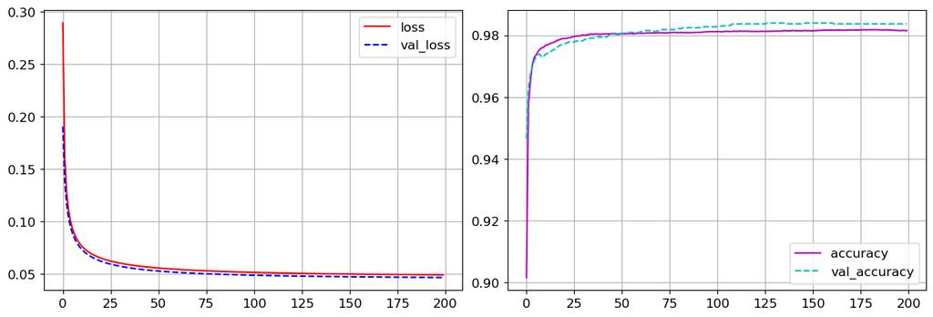

```python
df_history_WD = pd.DataFrame(history.history)

plt.rc('font', size=12)
fig = plt.figure(figsize=(12, 4),constrained_layout=True)
fig.tight_layout()

plt.subplot(1,2,1)
plt.plot(df_history_WD['loss'], c='r', ls='-')
plt.plot(df_history_WD['val_loss'], c='b', ls='--')
plt.grid(True)
plt.legend(['loss', 'val_loss'])

plt.subplot(1,2,2)
plt.plot(df_history_WD['accuracy'], c='m', ls='-')
plt.plot(df_history_WD['val_accuracy'], c='c', ls='--')
plt.grid(True)
plt.legend(['accuracy', 'val_accuracy'])
```

- Let's use the deep & wide model to predict the test set

```python
## Make predictions
y_pred_WD = (model_WD.predict(X_test_scaled)).round()

## Check prediction score
accuracy_WD = accuracy_score(y_test, y_pred_WD)

print('model_WD accuracy:', str(accuracy_WD))
```

```
model_WD accuracy: 0.9838077827108905
```

## 1.5. Conclusion

In this project, I built and fine-tune two neural networks for binary classification problem to detect breast cancer.

- The first model is a **sequential neural network** which was optimised by fine-tuning various options of hyperparameters. The optimised model has 4 hidden layers (plus one output layer). Each hidden layer has 153 neurons.
- The second model is a **deep and wide neural network** and it was also optimised by considering various options for its hyperparameters.
- It's interesting to see that the **deep and wide neural network** has only **two hidden layers** with only **4 neurons each**. However, it still give a similar accuracy as the **sequnetial neural network**.
- It tells a story that sometime we don't need to go with very complicated & deep neural networks with many hidden layers and neurons to get good predictions. Instead, a simple model such as the **deep and wide** model below still work well. Moreover, training and using this model are more efficiency than other complicated ones.

```python
print('A dense deep neural network using "he-normal" activation function:')
print("Model parameters: ",model_he_params)

print("Model summary: ")
print(model_he.summary())

print('Model accuracy:', str(accuracy_he))
```

```
A dense deep neural network using "he-normal" activation function:
Model parameters:  {'activation': 'LeakyReLU', 'learning_rate': 0.005172415563224279, 'n_hidden': 4, 'n_neurons': 153, 'optimizer': 'SGD'}
Model summary:
Model: "sequential_30"
_________________________________________________________________
 Layer (type)                Output Shape              Param #
=================================================================
 dense_216 (Dense)           (None, 153)               4590

 dense_217 (Dense)           (None, 153)               23562

 dense_218 (Dense)           (None, 153)               23562

 dense_219 (Dense)           (None, 153)               23562

 dense_220 (Dense)           (None, 1)                 154

=================================================================
Total params: 75,430
Trainable params: 75,430
Non-trainable params: 0
_________________________________________________________________
None
Model accuracy: 0.9843301123008619
```

```python
print('A deep and wide neural network using the same he-normal activation function:')
print(model_WD.summary())

print('Model accuracy:', str(accuracy_WD))
```

```
A deep and wide neural network using the same he-normal activation function:
Model: "model"
__________________________________________________________________________________________________
 Layer (type)                   Output Shape         Param #     Connected to
==================================================================================================
 input_94 (InputLayer)          [(None, 29)]         0           []

 dense_597 (Dense)              (None, 4)            120         ['input_94[0][0]']

 dense_598 (Dense)              (None, 4)            20          ['dense_597[0][0]']

 concatenate (Concatenate)      (None, 33)           0           ['input_94[0][0]',
                                                                  'dense_598[0][0]']

 dense_599 (Dense)              (None, 1)            34          ['concatenate[0][0]']

==================================================================================================
Total params: 174
Trainable params: 174
Non-trainable params: 0
__________________________________________________________________________________________________
None
Model accuracy: 0.9838077827108905
```